# Reproducible Research: Peer Assessment 1

## Introduction

This assessment analyzes data generated from wearable activity monitors. The data consists of two months of data from an anonymous individual collected during the months of October and November, 2012, and inclue the number of steps taken in 5-minute intervals each day.

## Data

The variables in the dataset are: * steps: Number of steps taken during a 5-minute interval (missing values are coded as NA) * date: The date on which the measurement was taken in YYYY-MM-DD format * interval: Identifier for the 5-minute interval in which measurement was taken.

The dataset is stored in a comma-separated-value (CSV) file and there are a total of 17,568 observations in this dataset.

## Loading and preprocessing the data

From within our Github repository, the dataset is stored as “activity.csv”. We need to extract it by reading it into a dataframe with the read.csv() method:

```r
activity = read.csv("./activity.csv", header = T)
str(activity)
```

```
## 'data.frame':    17568 obs. of  3 variables:
##  $ steps   : int  NA NA NA NA NA NA NA NA NA NA ...
##  $ date    : Factor w/ 61 levels "2012-10-01","2012-10-02",..: 1 1 1 1 1 1 1 1 1 1 ...
##  $ interval: int  0 5 10 15 20 25 30 35 40 45 ...
```

Right away, it's noticeable that NA's are present along the entirty of certain days. As this suggests untracked activity, it's best to delete those days from our set

```r
activity = activity[!is.na(activity[1:nrow(activity), 1]), ]
```

Let's double check to make sure we've removed all NA's from the first column

```r
sum(is.na(activity[1:nrow(activity), 1]))  #Should be 0
```

```
## [1] 0
```

## What is mean total number of steps taken per day?

Now that we have full values for each day, we can make a histogram and calculate the mean and median steps per day.

First, though, we need a frame that stores daily step values for each day.

```r
daily_steps = data.frame(day = factor(), steps = factor())

for (i in 1:length(unique(activity[, 2]))) {

    step_count = 0
    current_day = unique(activity[, 2])[i]
    group = which(activity[, 2] == current_day)
    for (g in group) {
        step_count = step_count + activity[g, 1]
    }

    daily_steps = rbind(daily_steps, data.frame(day = current_day, steps = step_count))
}
```

Next, we construct the histogram by plotting the values in our day column against their counts in the step column

[output not shown]

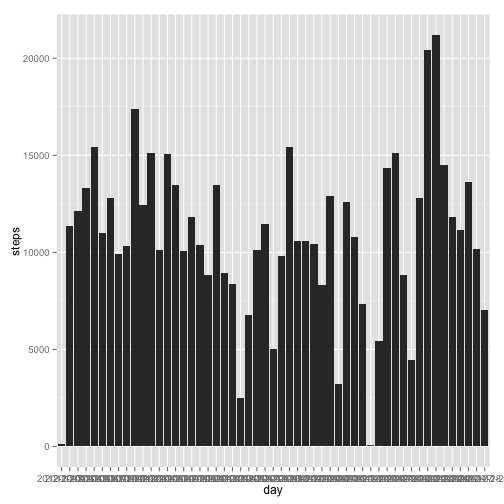

```r
library(ggplot2)

g = ggplot(daily_steps, aes(x = day, y = steps)) + geom_histogram()
print(g)
```

Furthermore, now that our daily counts our binned up in a specialized data frame, calculating the mean and median number of steps taken per day is fairly trivial. We'll just perform the opertions directly on the “steps” column in daily_steps

```r
avg_daily_steps = mean(daily_steps$steps)
avg_daily_steps
```

```
## [1] 10766
```

```r
median_daily_steps = median(daily_steps$steps)
median_daily_steps
```

```
## [1] 10765
```

## What is the average daily activity pattern?

Here, we're looking to compute the daily averages FOR EACH TIME INTERVAL. For example, the average of the 10th-15th minute interval is the average number of steps reported for it across all days.

We'll store those values in a dataframe, and then make a time-series line graph by laying the intervals out along the x-axis and the average step value along the y-axis.

```r
interval_averages = data.frame(interval = numeric(288), steps = numeric(288))

for (i in 1:length(unique(activity[, 2]))) {
    # iterate over each unique date

    # get all intervals corresponding to this date
    intervals = activity[which(activity[, 2] == activity[i, 2]), ][3]

    # get all steps corresponding to this date
    steps = list(activity[((i - 1) * 288):(((i - 1) * 288) + 287), 1])

    # cumulatively build the steps count for each interval so we have a total to
    # average at the end
    interval_averages = data.frame(interval = intervals, steps = interval_averages$steps +
        steps[[1]])
}
```

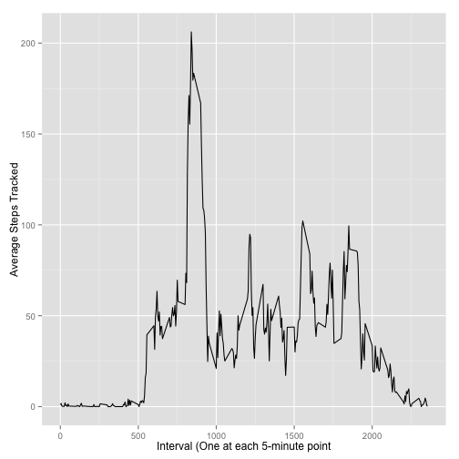

```r
# We have a frame that contains total steps for each interval -- now we just
# need to convert those totals to averages.

interval_averages[, 2] = interval_averages[, 2]/length(unique(activity[, 2]))
names(interval_averages)[2] = "average_steps"

# Now plot!
interval_plot = ggplot(interval_averages, aes(x = interval, y = average_steps)) +
    geom_line() + xlab("Interval (One at each 5-minute point") + ylab("Average Steps Tracked")

print(interval_plot)
```